# Clustering

## Clustering

```python
# Set up library imports and define a helper function to display numpy arrays.
import numpy as np
import matplotlib.pyplot as plt
from sklearn.neighbors import NearestNeighbors
from sklearn.cluster import KMeans
from collections import defaultdict
```

```python
# Useful in beautifying numpy arrays.
from IPython.display import HTML, display
import tabulate
def pp(a, show_head=False):
    '''
    args: show_head -> if True print only first 5 rows.
    return: None
    '''
    if a.ndim < 2:
        a = [a]
    if show_head:
        display(HTML(tabulate.tabulate(a[:5], tablefmt='html')))
        return
    display(HTML(tabulate.tabulate(a, tablefmt='html')))
```

## Unsupervised Learning

### Kmeans Clustering

So far, we dealt with datasets in which we're also given a label for each datapoint (supervised setting). Now, we'll deal with datasets in which we don't know the labels (unsupervised setting). In this tutorial, given a training set, we want to group the data into a few cohesive `clusters`- called clustering.

`Algorithm:`

- Initilaize k clusters randomly (we can pick any k training examples).
- Repeat Until Convergence:
  1. Assign each training example to a cluster based on how close it is to a cluster.
  2. Compute mean of all the points assigned to cluster i- that mean is your new guess for cluster i.

### Demo

Play with this [k-meas clustering demo](https://www.naftaliharris.com/blog/visualizing-k-means-clustering/).

### K-means

Let's consider a randmom synthetic datset.

```
[-6, 6, -3, 3]
```

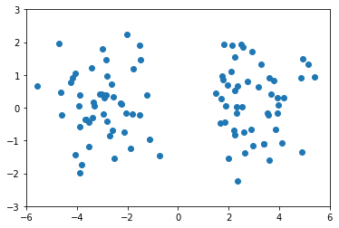

```python
np.random.seed(0)
X = np.vstack([np.random.randn(50,2) + [-3,0], np.random.randn(50,2) + [3,0]])
plt.scatter(X[:,0], X[:,1])
plt.axis([-6,6,-3,3])
```

Even if you weren’t to look at the code that generated these points, it should be fairly apparent that there are two different clusters of points here. The goal of the k-means algorithm is to find a set of k “centers” (that is, points μ(i)∈Rn) such that every data point is close to at least one center. By doing so, we can also associate each point with it’s closest center, and use this as an indication of which cluster it belong to.

### Train a Kmeans and Find Centroids Assigned

```python
kmeans = KMeans(n_clusters=2, random_state=0).fit(X)
pp(kmeans.labels_) # label (either cluster assignment) of each datapoint
```

| 1 | 1 | 1 | 1 | 1 | 1 | 1 | 1 | 1 | 1 | 1 | 1 | 1 | 1 | 1 | 1 | 1 | 1 | 1 | 1 | 1 | 1 | 1 | 1 | 1 | 1 | 1 | 1 | 1 | 1 | … |
| --- | --- | --- | --- | --- | --- | --- | --- | --- | --- | --- | --- | --- | --- | --- | --- | --- | --- | --- | --- | --- | --- | --- | --- | --- | --- | --- | --- | --- | --- | --- |

[Notes on k-means Clustering](http://cs229.stanford.edu/notes/cs229-notes7a.pdf) for a theoretical treatment.

### Final Centroids Found:

```python
kmeans.cluster_centers_
```

```
array([[ 2.98127847,  0.18274747],
       [-2.98319384,  0.10280987]])
```

## Nearest Neighbour

We've already seen Nearest Neighbour in the context of classification in `tutorial 4`. Here, we'll use it for clustering (unsupervised learning/no labels given).

```python
neigh = NearestNeighbors(n_neighbors=3, radius=0.4)
neigh.fit(X)
```

[output not shown]

```python
X.shape
```

```
(100, 2)
```

## Closest points for each example in X

[More in Docs](https://scikit-learn.org/stable/modules/generated/sklearn.neighbors.NearestNeighbors.html#sklearn.neighbors.NearestNeighbors.radius_neighbors)

### Indexes of Closest datapoints

`For each example`

Change radius to strict similarity criterion and run the subsequent cells.

```python
# Print Closest indexes for each of the 100 examples
closes_points_indexes = neigh.radius_neighbors(radius=3)[1] # points within radius 1
pp(closes_points_indexes)
```

| [ 1 2 3 4 5 6 7 8 9 11 12 13 14 15 17 18 19 22 25 26 27 28 29 30 32 34 35 36 37 38 39 40 41 42 43 44 45 46 47 48 49 70 95] | [ 0 3 4 5 6 7 8 11 13 14 15 17 18 19 21 23 25 27 28 32 34 35 37 39 40 42 43 44 45 46 47 48 49] | [ 0 3 4 5 6 7 8 9 11 12 13 14 15 16 17 18 19 20 22 26 27 28 29 30 31 32 34 35 36 37 38 39 41 42 43 46 47 49 70 74] | [ 0 1 2 4 5 6 7 8 9 11 12 13 14 15 16 17 18 19 20 22 23 24 25 26 27 28 29 30 31 32 33 34 35 36 37 38 39 40 41 42 43 44 45 46 47 48 49] | [ 0 1 2 3 5 6 7 8 9 10 11 13 14 15 16 17 18 19 20 21 22 23 24 25 26 27 28 29 30 31 32 33 34 35 36 37 38 39 40 41 42 43 44 45 46 47 48 49] | [ 0 1 2 3 4 6 7 8 9 10 11 13 14 15 17 18 19 21 22 23 24 25 26 27 28 29 30 32 33 34 35 36 37 38 39 40 42 43 44 45 46 47 48 49] | [ 0 1 2 3 4 5 7 8 9 11 12 13 14 15 16 17 18 19 20 22 23 24 25 26 27 28 29 30 31 32 33 34 35 36 37 38 39 40 41 42 43 44 45 46 47 48 49] | [ 0 1 2 3 4 5 6 8 9 11 12 13 14 15 16 17 18 19 20 21 22 23 24 25 26 27 28 29 30 31 32 33 34 35 36 37 38 39 40 41 42 43 44 45 46 47 48 49] | [ 0 1 2 3 4 5 6 7 9 11 12 13 14 15 16 17 18 19 20 22 23 25 26 27 28 29 30 31 32 34 35 36 37 38 39 40 41 42 43 44 45 46 47 48 49] | [ 0 2 3 4 5 6 7 8 11 12 13 14 15 16 17 18 19 20 22 23 24 25 26 27 28 29 30 31 32 33 34 35 36 37 38 39 40 41 42 43 44 45 46 47 48 49] | [ 4 5 13 15 17 19 20 21 22 23 24 25 26 27 28 29 30 31 32 33 34 38 39 40 44 45 46 47 48 49] | [ 0 1 2 3 4 5 6 7 8 9 12 13 14 15 16 17 18 19 20 22 23 24 25 26 27 28 29 30 31 32 33 34 35 36 37 38 39 40 41 42 43 44 45 46 47 48 49] | [ 0 2 3 6 7 8 9 11 13 15 18 19 22 26 27 28 32 35 36 37 39 41 43 47 49 70 74 95 79 83] | [ 0 1 2 3 4 5 6 7 8 9 10 11 12 14 15 16 17 18 19 20 21 22 23 24 25 26 27 28 29 30 31 32 33 34 35 36 37 38 39 40 41 42 43 44 45 46 47 48 49] | [ 0 1 2 3 4 5 6 7 8 9 11 13 15 17 18 19 22 23 25 27 28 29 30 32 34 35 36 37 39 40 42 43 44 45 46 47 48 49] | [ 0 1 2 3 4 5 6 7 8 9 10 11 12 13 14 16 17 18 19 20 21 22 23 24 25 26 27 28 29 30 31 32 33 34 35 36 37 38 39 40 41 42 43 44 45 46 47 48 49] | [ 2 3 4 6 7 8 9 11 13 15 17 19 20 22 23 24 25 26 27 28 29 30 31 32 33 34 35 36 37 38 39 40 41 43 47 49] | [ 0 1 2 3 4 5 6 7 8 9 10 11 13 14 15 16 18 19 20 21 22 23 24 25 26 27 28 29 30 31 32 33 34 35 36 37 38 39 40 41 42 43 44 45 46 47 48 49] | [ 0 1 2 3 4 5 6 7 8 9 11 12 13 14 15 17 19 22 23 25 26 27 28 29 30 32 33 34 35 36 37 38 39 40 41 42 43 44 45 46 47 48 49] | [ 0 1 2 3 4 5 6 7 8 9 10 11 12 13 14 15 16 17 18 20 21 22 23 24 25 26 27 28 29 30 31 32 33 34 35 36 37 38 39 40 41 42 43 44 45 46 47 48 49] | [ 2 3 4 6 7 8 9 10 11 13 15 16 17 19 22 23 24 25 26 27 28 29 30 31 32 33 34 35 36 37 38 39 40 41 43 44 45 46 47 49] | [ 1 4 5 7 10 13 15 17 19 22 23 24 25 27 28 29 30 33 34 38 39 40 44 45 46 47 48 49] | [ 0 2 3 4 5 6 7 8 9 10 11 12 13 14 15 16 17 18 19 20 21 23 24 25 26 27 28 29 30 31 32 33 34 35 36 37 38 39 40 41 43 44 45 46 47 48 49] | [ 1 3 4 5 6 7 8 9 10 11 13 14 15 16 17 18 19 20 21 22 24 25 26 27 28 29 30 31 32 33 34 35 37 38 39 40 41 42 43 44 45 46 47 48 49] | [ 3 4 5 6 7 9 10 11 13 15 16 17 19 20 21 22 23 25 26 27 28 29 30 31 32 33 34 35 36 37 38 39 40 41 43 44 45 46 47 48 49] | [ 0 1 3 4 5 6 7 8 9 10 11 13 14 15 16 17 18 19 20 21 22 23 24 26 27 28 29 30 31 32 33 34 35 36 37 38 39 40 41 42 43 44 45 46 47 48 49] | [ 0 2 3 4 5 6 7 8 9 10 11 12 13 15 16 17 18 19 20 22 23 24 25 27 28 29 30 31 32 33 34 35 36 37 38 39 40 41 43 44 45 46 47 49] | [ 0 1 2 3 4 5 6 7 8 9 10 11 12 13 14 15 16 17 18 19 20 21 22 23 24 25 26 28 29 30 31 32 33 34 35 36 37 38 39 40 41 42 43 44 45 46 47 48 49] | [ 0 1 2 3 4 5 6 7 8 9 10 11 12 13 14 15 16 17 18 19 20 21 22 23 24 25 26 27 29 30 31 32 33 34 35 36 37 38 39 40 41 42 43 44 45 46 47 48 49] | [ 0 2 3 4 5 6 7 8 9 10 11 13 14 15 16 17 18 19 20 21 22 23 24 25 26 27 28 30 31 32 33 34 35 36 37 38 39 40 41 43 44 45 46 47 48 49] | … |
| --- | --- | --- | --- | --- | --- | --- | --- | --- | --- | --- | --- | --- | --- | --- | --- | --- | --- | --- | --- | --- | --- | --- | --- | --- | --- | --- | --- | --- | --- | --- |

### Distances of Closest datapoints

`For each example`

```python
# print correspondig distances
closes_points_distances = neigh.radius_neighbors(radius=2.5)[0] # points within radius 1
pp(closes_points_distances)
```

| [2.00125651 1.38131852 0.98321179 1.86730039 1.93276734 1.04095661 1.32186205 0.66279136 1.9179434 1.45403208 1.92223566 1.81590286 1.09392835 1.60925523 2.12599071 0.96356768 2.26315759 2.42329617 1.… | [2.00125651 2.39242195 2.12617245 1.14694608 2.13037065 1.98080156 2.49974883 0.94985634 2.03676127 2.47089563 1.06854515 2.07346736 2.14234074 2.12661442 0.61533122 2.42906908 2.36813325 1.71666114 1… | [1.38131852 1.23446157 2.41042781 1.55951421 1.93533006 0.85770345 1.5593633 1.03030645 0.62399912 1.98574971 2.4694347 2.18409103 2.48865783 2.27090674 2.35374105 2.43759486 2.38704088 2.35999359 2.2… | [0.98321179 2.39242195 1.23446157 1.19383853 1.79659631 0.3320945 0.70108454 0.54664466 0.94849187 0.59698423 1.85454845 0.90503929 1.72228013 0.95532211 1.33397472 1.38243167 1.34590641 2.36729116 1.… | [1.86730039 2.12617245 2.41042781 1.19383853 1.07256525 0.91127175 0.5524637 1.7118753 1.33144509 2.46179539 1.50506479 0.61606655 1.94870803 0.26019593 0.35287056 1.55085956 0.76742787 2.06029443 2.2… | [1.93276734 1.14694608 1.79659631 1.07256525 1.46850282 1.16001481 2.13923109 2.31454914 2.31155959 1.64439722 1.38881757 1.07616623 1.38803045 1.11507094 1.8351879 1.91577012 2.00207352 1.55215799 2.… | [1.04095661 2.13037065 1.55951421 0.3320945 0.91127175 1.46850282 0.38150146 0.80260178 1.0736879 0.87000624 2.18177243 0.77911369 1.55300883 0.65812711 1.10949182 1.17818558 1.22413164 2.37727483 1.3… | [1.32186205 1.98080156 1.93533006 0.70108454 0.5524637 1.16001481 0.38150146 1.1803787 1.19494987 1.1551242 0.65557654 1.57337763 0.29232096 0.81138926 1.17180093 1.04658671 2.30276848 1.22669784 1.75… | [0.66279136 2.49974883 0.85770345 0.54664466 1.7118753 2.13923109 0.80260178 1.1803787 1.3475562 0.82754239 1.47043929 1.44843209 1.67496418 1.4606631 1.87713056 1.43204324 1.8839122 2.01722305 2.4618… | [1.9179434 1.5593633 0.94849187 1.33144509 2.31454914 1.0736879 1.19494987 1.3475562 0.56261506 2.04669189 0.71848846 1.24236164 1.64666437 1.20743235 2.25175261 0.89164342 1.47454358 0.92192291 2.261… | [2.46179539 2.2604523 2.36725196 1.54904806 2.31668342 1.30608186 1.27768205 1.67884508 2.17123766 2.13609637 0.94231768 1.75223029 2.08536572 2.31969642 1.40968491 1.53547852 2.22379381] | [1.45403208 1.03030645 0.59698423 1.50506479 2.31155959 0.87000624 1.1551242 0.82754239 0.56261506 1.57548394 0.98905877 2.31030731 1.32608752 2.14580745 1.50901157 1.97866224 1.32679669 2.02953495 1.… | [1.92223566 0.62399912 1.85454845 2.18177243 1.47043929 2.04669189 1.57548394 2.34217273 2.20921672 1.15147635 2.01976411 1.80594923 1.67762511] | [1.81590286 1.98574971 0.90503929 0.61606655 1.64439722 0.77911369 0.65557654 1.44843209 0.71848846 0.98905877 2.22606469 0.575794 2.0220166 0.52248578 1.82592544 0.44812417 1.64845306 0.60944816 1.61… | [1.09392835 0.94985634 2.4694347 1.72228013 1.94870803 1.38881757 1.55300883 1.57337763 1.67496418 2.31030731 2.22606469 1.75759202 2.29368584 0.40345639 1.87625628 1.87391281 2.31044276 1.56285729 2.… | [1.60925523 2.03676127 2.18409103 0.95532211 0.26019593 1.07616623 0.65812711 0.29232096 1.4606631 1.24236164 1.32608752 0.575794 1.75759202 0.54960805 1.35487908 0.87011168 2.16376204 2.4366457 1.052… | [1.64666437 2.14580745 2.0220166 2.20428086 1.75151372 0.58336837 1.58838808 1.91135069 2.36771142 0.88452092 2.47467343 1.63778716 1.63548 0.26523265 1.90472214 2.03283551 2.16008265 1.82866327 1.402… | [2.12599071 2.47089563 2.48865783 1.33397472 0.35287056 1.38803045 1.10949182 0.81138926 1.87713056 1.20743235 2.2604523 1.50901157 0.52248578 2.29368584 0.54960805 2.20428086 1.89338448 0.46034217 1.… | [0.96356768 1.06854515 2.27090674 1.38243167 1.55085956 1.11507094 1.17818558 1.17180093 1.43204324 2.25175261 1.97866224 1.82592544 0.40345639 1.35487908 1.89338448 2.20924333 2.39133665 2.27680635 1… | [2.26315759 2.35374105 1.34590641 0.76742787 1.8351879 1.22413164 1.04658671 1.8839122 0.89164342 2.36725196 1.32679669 0.44812417 0.87011168 1.75151372 0.46034217 2.20924333 1.29865594 0.18274958 1.3… | [2.36729116 2.06029443 2.37727483 2.30276848 1.47454358 2.02953495 1.64845306 2.16376204 0.58336837 1.72505947 1.29865594 1.12010149 2.20697931 1.33309196 1.81339375 0.58862404 2.11129189 2.05191441 1… | [2.22304261 1.91577012 1.54904806 2.4366457 2.25057832 1.25787011 2.16548672 1.76156208 2.26579202 2.42067751 1.48993641 2.06007557 2.35261229 1.18118751 1.09876235 1.49282185 2.14812124 2.40883974 1.… | [2.42329617 2.43759486 1.48763211 0.9409748 2.00207352 1.38851436 1.22669784 2.01722305 0.92192291 2.31668342 1.40733437 0.60944816 1.052585 1.58838808 0.61603479 2.39133665 0.18274958 1.12010149 1.42… | [2.39070172 1.20670451 1.55215799 2.11792763 1.75374543 2.26141556 1.30608186 1.61766452 1.46328482 1.09755649 1.38383126 2.20697931 1.25787011 1.42473128 1.05401694 0.52937959 2.09398982 1.27341626 1… | [1.63422834 2.42266238 2.39836456 2.12907247 2.03089464 1.27768205 1.65985312 1.86493424 1.91135069 1.31869127 1.22983655 1.33309196 2.16548672 1.12700218 1.05401694 0.93579644 1.46752454 1.71039982 1… | [1.9224455 0.792602 1.48992019 1.67760307 1.34038708 2.46180102 1.73223315 1.67884508 2.09094505 1.102488 1.05045035 2.36771142 0.59411343 2.27680635 0.85627675 1.81339375 1.76156208 0.91073567 0.5293… | [2.38704088 1.78706938 1.64260211 1.82032643 1.79011617 2.22959863 0.88622373 1.44344802 1.13872854 1.69501251 0.88452092 1.34686775 0.88696645 0.58862404 0.74255878 2.09398982 1.46752454 1.61404132 1… | [1.79245602 2.07346736 2.35999359 1.13712483 0.07710361 1.04029706 0.84670335 0.48144259 1.64881449 1.32705391 1.47201584 0.61994099 1.87625628 0.18987742 0.41976413 1.47746551 0.81413254 2.11129189 2… | [1.70034347 2.14234074 2.20941335 0.99330706 0.20125034 1.15440776 0.71766722 0.37863386 1.51513076 1.18255479 1.31451169 0.49009558 1.87391281 0.11640005 2.47467343 0.43943556 1.47112303 0.75612617 2… | [1.5984492 0.93814972 1.97671329 1.47705385 1.28354125 2.13422677 1.06722853 2.17123766 1.54603974 0.70237455 1.08253621 1.63778716 0.59286189 2.43441668 0.25428226 1.13552692 0.14566286 1.29716503 0.… | … |
| --- | --- | --- | --- | --- | --- | --- | --- | --- | --- | --- | --- | --- | --- | --- | --- | --- | --- | --- | --- | --- | --- | --- | --- | --- | --- | --- | --- | --- | --- | --- |

Using these closest indexes we can cluster the closest examples.

In the code below, keeping track of datapoints already assigned to a cluster, we simply put the closest datapoints for each example in one cluster (a simple approach).

```python
clusters = defaultdict(list)
already_assigned_datapoints = set()
cluster_id = 0
for idx, closest_datapoints in enumerate(closes_points_indexes):
    "Add these points to set- to keep track"
    # first add this element
    if idx not in already_assigned_datapoints:
        already_assigned_datapoints.add(idx)
        clusters[cluster_id].append(idx)
    # now add its closed neighbours
    for _datapoint in closest_datapoints:
        if _datapoint not in already_assigned_datapoints:
            already_assigned_datapoints.add(_datapoint)
            clusters[cluster_id].append(_datapoint)
    cluster_id = cluster_id + 1
```

### Arbitrary Cluster id (on the left)- Elements in that cluster (on the right)

```python
array = np.array(list(clusters.items()))
pp(array) # cluster id on the left is arbitrary.
```

| 0 | [0, 1, 2, 3, 4, 5, 6, 7, 8, 9, 11, 12, 13, 14, 15, 17, 18, 19, 22, 25, 26, 27, 28, 29, 30, 32, 34, 35, 36, 37, 38, 39, 40, 41, 42, 43, 44, 45, 46, 47, 48, 49, 70, 95] |
| --- | --- |
| 1 | [21, 23] |
| 2 | [16, 20, 31, 74] |
| 3 | [24, 33] |
| 4 | [10] |
| 12 | [79, 83] |
| 50 | [50, 62, 66, 76, 77, 88, 89, 90, 91, 53, 96, 71, 60, 69, 97, 64, 59, 92, 68, 98, 81, 55, 84, 85, 86, 78, 54, 58, 99, 72] |
| 51 | [51, 56, 57, 63, 65, 67, 73, 52, 75, 80, 82, 87, 93, 94, 61] |